# A4_Tadepalli_Sai_Eshwar

Sai Eshwar Tadepalli

2023-06-14

## 1 - Set up, data import, data exploration, data partitioning, and inspection code

1.A. Package loading, and data import.

Set the working directory to the directory where your rmarkdown program file resides in rstudio using getwd() and setwd(). For example,

```
     mydir <- getwd()
     setwd(mydir)
```

Load character strings as character fields. Show the overall structure and summary of the input data. Other than the Name, transform all other non-numeric fields to be factor variables.

```r
# Load libraries
library(rmarkdown)
library(psych)
library(rpart)
library(RWeka)
library(caret)
library(rminer)
```

```r
library(matrixStats)
library(knitr)

cloud_wd <- getwd()
setwd(cloud_wd)

# Read csv files
sales_filtered <- read.csv(file = "NA_sales_filtered.csv", stringsAsFactors = FALSE)

# Summary and Structure of sales_filtered df
str(sales_filtered)
```

```
## 'data.frame':    6345 obs. of  9 variables:
##  $ Name        : chr  "Final Fantasy VII" "Final Fantasy X" "The Sims 3" "Final Fantasy VIII" ...
##  $ Platform    : chr  "PS" "PS2" "PC" "PS" ...
##  $ Genre       : chr  "Role-Playing" "Role-Playing" "Simulation" "Role-Playing" ...
##  $ Rating      : chr  "T" "T" "T" "T" ...
##  $ Critic_Score: int  92 92 86 90 96 88 92 96 93 87 ...
##  $ Critic_Count: int  20 53 75 24 15 29 97 105 57 22 ...
##  $ User_Score  : int  91 86 75 85 90 84 82 87 72 80 ...
##  $ User_Count  : int  1282 1056 886 644 367 135 3712 5187 2182 78 ...
##  $ NA_Sales    : num  3.01 2.91 0.99 2.28 3.27 2.93 2.77 3.27 0.08 3.11 ...
```

```r
summary(sales_filtered)
```

```
##      Name             Platform            Genre              Rating
##  Length:6345        Length:6345        Length:6345        Length:6345
##  Class :character   Class :character   Class :character   Class :character
##  Mode  :character   Mode  :character   Mode  :character   Mode  :character
##
##
##
##   Critic_Score    Critic_Count      User_Score      User_Count
##  Min.   :13.00   Min.   :  3.00   Min.   : 5.00   Min.   :    4.0
##  1st Qu.:61.00   1st Qu.: 14.00   1st Qu.:64.00   1st Qu.:   10.0
##  Median :72.00   Median : 25.00   Median :74.00   Median :   24.0
##  Mean   :69.82   Mean   : 28.97   Mean   :70.77   Mean   :  152.7
##  3rd Qu.:80.00   3rd Qu.: 40.00   3rd Qu.:81.00   3rd Qu.:   77.0
##  Max.   :98.00   Max.   :113.00   Max.   :95.00   Max.   :10665.0
##     NA_Sales
##  Min.   :0.0100
##  1st Qu.:0.0800
##  Median :0.1700
##  Mean   :0.3542
##  3rd Qu.:0.4100
##  Max.   :3.4900
```

```r
sales_filtered$Platform = factor(sales_filtered$Platform)
sales_filtered$Genre = factor(sales_filtered$Genre)
sales_filtered$Rating = factor(sales_filtered$Rating)

str(sales_filtered)
```

```
## 'data.frame':    6345 obs. of  9 variables:
##  $ Name        : chr  "Final Fantasy VII" "Final Fantasy X" "The Sims 3" "Final Fantasy VIII" ...
##  $ Platform    : Factor w/ 16 levels "3DS","DS","GBA",..: 6 7 5 6 6 7 8 8 5 6 ...
##  $ Genre       : Factor w/ 12 levels "Action","Adventure",..: 8 8 10 8 3 9 1 1 8 1 ...
##  $ Rating      : Factor w/ 5 levels "E","E10+","M",..: 5 5 5 5 5 5 5 5 5 5 ...
##  $ Critic_Score: int  92 92 86 90 96 88 92 96 93 87 ...
##  $ Critic_Count: int  20 53 75 24 15 29 97 105 57 22 ...
##  $ User_Score  : int  91 86 75 85 90 84 82 87 72 80 ...
##  $ User_Count  : int  1282 1056 886 644 367 135 3712 5187 2182 78 ...
##  $ NA_Sales    : num  3.01 2.91 0.99 2.28 3.27 2.93 2.77 3.27 0.08 3.11 ...
```

```r
summary(sales_filtered)
```

```
##      Name              Platform             Genre          Rating
##  Length:6345        PS2    :1135   Action      :1549   E      :1968
##  Class :character   X360   : 848   Sports      : 921   E10+   : 877
##  Mode  :character   PS3    : 749   Shooter     : 798   M      :1295
##                     XB     : 578   Role-Playing: 643   missing:  23
##                     Wii    : 475   Racing      : 537   T      :2182
##                     DS     : 457   Platform    : 386
##                     (Other):2103   (Other)     :1511
##   Critic_Score    Critic_Count      User_Score      User_Count
##  Min.   :13.00   Min.   :  3.00   Min.   : 5.00   Min.   :    4.0
##  1st Qu.:61.00   1st Qu.: 14.00   1st Qu.:64.00   1st Qu.:   10.0
##  Median :72.00   Median : 25.00   Median :74.00   Median :   24.0
##  Mean   :69.82   Mean   : 28.97   Mean   :70.77   Mean   :  152.7
##  3rd Qu.:80.00   3rd Qu.: 40.00   3rd Qu.:81.00   3rd Qu.:   77.0
##  Max.   :98.00   Max.   :113.00   Max.   :95.00   Max.   :10665.0
##
##     NA_Sales
##  Min.   :0.0100
##  1st Qu.:0.0800
##  Median :0.1700
##  Mean   :0.3542
##  3rd Qu.:0.4100
##  Max.   :3.4900
##
```

1.B. Use pairs.panels to show distributions and correlations of all of the numeric variables.

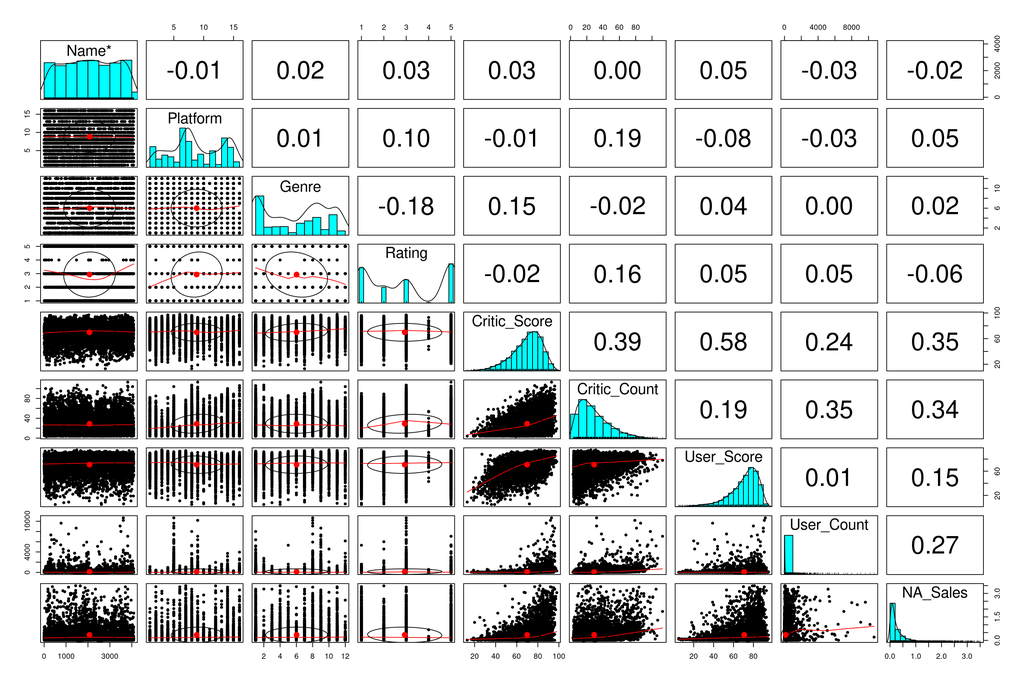

```r
pairs.panels(sales_filtered)
```

1.C. Remove the Name variable from the data frame. All subsequent models should have this column excluded. Build a linear regression model. Show the summary of the model to understand the significance and coefficients of the predictors in the model and the overall model fit. Note that the purpose of this task is not to build a predictive model. Rather, it is often a good idea to explore a data set with white-box models like linear regression (for numeric target variable) or decision tree (for factor target variable).

```r
sales_filtered <- sales_filtered[,-1]
lm_model <- lm(NA_Sales ~ ., data = sales_filtered)
summary(lm_model)
```

```
##
## Call:
## lm(formula = NA_Sales ~ ., data = sales_filtered)
##
## Residuals:
##     Min      1Q  Median      3Q     Max
## -1.9381 -0.2315 -0.0818  0.0978  3.1769
##
## Coefficients:
##                     Estimate Std. Error t value Pr(>|t|)
## (Intercept)       -4.045e-01  4.796e-02  -8.435  < 2e-16 ***
## PlatformDS         1.547e-01  4.088e-02   3.783 0.000156 ***
## PlatformGBA        1.705e-01  4.573e-02   3.729 0.000194 ***
## PlatformGC         8.918e-02  4.276e-02   2.085 0.037071 *
## PlatformPC        -3.054e-01  4.554e-02  -6.706 2.17e-11 ***
## PlatformPS         4.075e-01  5.080e-02   8.020 1.25e-15 ***
## PlatformPS2        1.954e-01  3.851e-02   5.074 4.00e-07 ***
## PlatformPS3        9.718e-02  3.929e-02   2.473 0.013422 *
## PlatformPS4       -7.379e-02  4.670e-02  -1.580 0.114165
## PlatformPSP        4.007e-02  4.201e-02   0.954 0.340130
## PlatformPSV       -1.176e-01  5.741e-02  -2.049 0.040509 *
## PlatformWii        2.401e-01  4.070e-02   5.898 3.87e-09 ***
## PlatformWiiU       2.866e-02  5.892e-02   0.487 0.626616
## PlatformX360       1.387e-01  3.906e-02   3.551 0.000386 ***
## PlatformXB         2.122e-02  4.060e-02   0.523 0.601157
## PlatformXOne       1.621e-01  4.988e-02   3.251 0.001157 **
## GenreAdventure    -1.254e-01  3.082e-02  -4.068 4.81e-05 ***
## GenreFighting      3.030e-03  2.539e-02   0.119 0.905002
## GenreMisc          8.375e-02  2.503e-02   3.346 0.000823 ***
## GenrePlatform     -3.135e-02  2.551e-02  -1.229 0.219107
## GenrePuzzle       -1.315e-01  4.298e-02  -3.059 0.002230 **
## GenreRacing       -4.130e-02  2.282e-02  -1.810 0.070341 .
## GenreRole-Playing -1.030e-01  2.038e-02  -5.052 4.50e-07 ***
## GenreShooter       2.908e-03  1.894e-02   0.154 0.877966
## GenreSimulation    5.868e-02  2.951e-02   1.988 0.046825 *
## GenreSports       -2.387e-02  2.134e-02  -1.118 0.263445
## GenreStrategy     -1.726e-01  3.297e-02  -5.235 1.71e-07 ***
## RatingE10+        -5.782e-02  1.888e-02  -3.062 0.002205 **
## RatingM           -1.121e-01  2.107e-02  -5.322 1.06e-07 ***
## Ratingmissing     -2.244e-01  8.975e-02  -2.500 0.012451 *
## RatingT           -9.328e-02  1.679e-02  -5.557 2.86e-08 ***
## Critic_Score       1.049e-02  5.435e-04  19.298  < 2e-16 ***
## Critic_Count       6.122e-03  3.687e-04  16.605  < 2e-16 ***
## User_Score        -2.824e-03  4.930e-04  -5.729 1.06e-08 ***
## User_Count         2.027e-04  1.172e-05  17.287  < 2e-16 ***
## ---
## Signif. codes:  0 '***' 0.001 '**' 0.01 '*' 0.05 '.' 0.1 ' ' 1
##
## Residual standard error: 0.421 on 6310 degrees of freedom
## Multiple R-squared:  0.2787, Adjusted R-squared:  0.2749
## F-statistic: 71.72 on 34 and 6310 DF,  p-value: < 2.2e-16
```

1.D. Partition the dataset for simple hold-out evaluation – 70% for training and the other 30% for testing.

```r
# setting seed to a value for createDataPartition().
set.seed(500)
inTrain <- createDataPartition(sales_filtered$NA_Sales, p=0.7, list=FALSE)

# Assigning the rows in Sales filtered indexed by inTrain to create a train set
# Assign all other rows indexed by -inTrain to create a test set

train_target <- sales_filtered[inTrain,8]
test_target <- sales_filtered[-inTrain,8]
train_input <- sales_filtered[inTrain,-8]
test_input <- sales_filtered[-inTrain,-8]
```

1.E. Show the overall summaries of training and testing sets.

```r
summary(train_target)
```

```
##    Min. 1st Qu.  Median    Mean 3rd Qu.    Max.
##  0.0100  0.0800  0.1700  0.3486  0.4100  3.4900
```

```r
summary(test_target)
```

```
##    Min. 1st Qu.  Median    Mean 3rd Qu.    Max.
##  0.0100  0.0700  0.1700  0.3675  0.4100  3.4800
```

```r
summary(train_input)
```

```
##     Platform             Genre          Rating      Critic_Score
##  PS2    : 810   Action      :1096   E      :1374   Min.   :13.00
##  X360   : 600   Sports      : 637   E10+   : 604   1st Qu.:62.00
##  PS3    : 535   Shooter     : 571   M      : 924   Median :72.00
##  XB     : 395   Role-Playing: 435   missing:  17   Mean   :69.85
##  Wii    : 325   Racing      : 389   T      :1523   3rd Qu.:80.00
##  DS     : 318   Platform    : 262                  Max.   :98.00
##  (Other):1459   (Other)     :1052
##   Critic_Count     User_Score      User_Count
##  Min.   :  3.0   Min.   : 5.00   Min.   :    4.0
##  1st Qu.: 15.0   1st Qu.:64.00   1st Qu.:   10.0
##  Median : 25.0   Median :74.00   Median :   24.0
##  Mean   : 29.1   Mean   :70.97   Mean   :  151.5
##  3rd Qu.: 40.0   3rd Qu.:81.00   3rd Qu.:   79.0
##  Max.   :113.0   Max.   :95.00   Max.   :10665.0
##
```

```r
summary(test_input)
```

```
##     Platform            Genre         Rating     Critic_Score
##  PS2    :325   Action      :453   E      :594   Min.   :19.00
##  X360   :248   Sports      :284   E10+   :273   1st Qu.:61.00
##  PS3    :214   Shooter     :227   M      :371   Median :72.00
##  XB     :183   Role-Playing:208   missing:  6   Mean   :69.75
##  Wii    :150   Racing      :148   T      :659   3rd Qu.:80.00
##  DS     :139   Misc        :125                 Max.   :97.00
##  (Other):644   (Other)     :458
##   Critic_Count      User_Score      User_Count
##  Min.   :  4.00   Min.   : 6.00   Min.   :   4.0
##  1st Qu.: 14.00   1st Qu.:63.00   1st Qu.:  10.0
##  Median : 24.00   Median :74.00   Median :  24.0
##  Mean   : 28.66   Mean   :70.29   Mean   : 155.7
##  3rd Qu.: 39.00   3rd Qu.:81.00   3rd Qu.:  72.5
##  Max.   :107.00   Max.   :95.00   Max.   :9629.0
##
```

## 2 - lm, rpart and M5P model training and testing

2.A. Train three models using lm, rpart, and M5P on the training set (built in 1.D). Use the default settings of these methods throughout this assignment.

```r
# regression tree using rpart
sales_rpart_model <- rpart(train_target ~ ., data = train_input)
# generate predictions for the testing and training dataset
predictions_rpart_test <- predict(sales_rpart_model, test_input)
predictions_rpart_train <- predict(sales_rpart_model, train_input)

# M5P model tree
sales_m5p_model <- M5P(train_target ~ ., data = train_input)
# generate predictions for the model
predictions_m5p_test <- predict(sales_m5p_model, test_input)
predictions_m5p_train <- predict(sales_m5p_model, train_input)

# Linear Regression Model
sales_lm_model <- lm(train_target ~ ., data = train_input)
# generate predictions for the model
predictions_lm_test <- predict(sales_lm_model, test_input)
predictions_lm_train <- predict(sales_lm_model, train_input)
```

2.B. For each of the three models trained in 2.A, perform the following:

1. Show information about the model by specifying the model name, and summary(model name).

```r
# rpart
sales_rpart_model
```

```
## n= 4442
##
## node), split, n, deviance, yval
##       * denotes terminal node
##
##   1) root 4442 1018.85600 0.3485547
##     2) User_Count< 64.5 3186  327.04910 0.2414752
##       4) User_Count< 20.5 1989  112.81040 0.1831926 *
##       5) User_Count>=20.5 1197  196.25550 0.3383208
##        10) Genre=Action,Adventure,Fighting,Puzzle,Racing,Role-Playing,Shooter,Strategy 854   92.42932 0.2688759 *
##        11) Genre=Misc,Platform,Simulation,Sports 343   89.45349 0.5112245 *
##     3) User_Count>=64.5 1256  562.61180 0.6201752
##       6) Platform=3DS,PC,PSV 255   22.60052 0.1994510 *
##       7) Platform=DS,GBA,GC,PS,PS2,PS3,PS4,PSP,Wii,WiiU,X360,XB,XOne 1001  483.37550 0.7273526
##        14) User_Count< 680.5 880  338.01900 0.6378636
##          28) Platform=DS,PS3,PS4,PSP,WiiU,X360,XB,XOne 672  193.83370 0.5343750
##            56) Critic_Score< 75.5 254   21.15077 0.3196850 *
##            57) Critic_Score>=75.5 418  153.86160 0.6648325
##             114) Rating=E10+,M,missing,T 337   92.39604 0.5863205 *
##             115) Rating=E 81   50.74562 0.9914815 *
##          29) Platform=GBA,GC,PS,PS2,Wii 208  113.73620 0.9722115
##            58) Genre=Action,Adventure,Fighting,Platform,Puzzle,Role-Playing,Shooter,Strategy 173   66.95631 0.8531214 *
##            59) Genre=Misc,Racing,Simulation,Sports 35   32.19867 1.5608570 *
##        15) User_Count>=680.5 121   87.05620 1.3781820 *
```

```r
summary(sales_rpart_model)
```

```
## Call:
## rpart(formula = train_target ~ ., data = train_input)
##   n= 4442
##
##           CP nsplit rel error    xerror       xstd
## 1 0.12680443      0 1.0000000 1.0004513 0.05191247
## 2 0.05640445      1 0.8731956 0.8832803 0.04525221
## 3 0.02988553      3 0.7603867 0.7908909 0.04108025
## 4 0.01847299      4 0.7305011 0.7810381 0.04086979
## 5 0.01765029      5 0.7120282 0.7719569 0.03999315
## 6 0.01431133      6 0.6943779 0.7551679 0.03916103
## 7 0.01410672      7 0.6800665 0.7453640 0.03906951
## 8 0.01052158      8 0.6659598 0.7333396 0.03847264
## 9 0.01000000      9 0.6554382 0.7339641 0.03859961
##
## Variable importance
##   User_Count     Platform Critic_Count Critic_Score        Genre       Rating
##           41           23           10           10            8            6
##   User_Score
##            3
##
## Node number 1: 4442 observations,    complexity param=0.1268044
##   mean=0.3485547, MSE=0.2293688
##   left son=2 (3186 obs) right son=3 (1256 obs)
##   Primary splits:
##       User_Count   < 64.5   to the left,  improve=0.12680440, (0 missing)
##       Critic_Score < 80.5   to the left,  improve=0.11638060, (0 missing)
##       Critic_Count < 57.5   to the left,  improve=0.08514968, (0 missing)
##       Platform     splits as  LLRLLRRRRLLRRRLR, improve=0.02743587, (0 missing)
##       User_Score   < 73.5   to the left,  improve=0.01664242, (0 missing)
##   Surrogate splits:
##       Critic_Count < 45.5   to the left,  agree=0.810, adj=0.330, (0 split)
##       Platform     splits as  LLLLRLLLRLRLRLLR, agree=0.775, adj=0.205, (0 split)
##       Critic_Score < 82.5   to the left,  agree=0.768, adj=0.179, (0 split)
##       Rating       splits as  LLRLL, agree=0.746, adj=0.102, (0 split)
##       User_Score   < 92.5   to the left,  agree=0.717, adj=0.001, (0 split)
##
## Node number 2: 3186 observations,    complexity param=0.01765029
##   mean=0.2414752, MSE=0.1026519
##   left son=4 (1989 obs) right son=5 (1197 obs)
```

[output cut: 118 more lines]

```
##   Surrogate splits:
##       Genre      splits as  LLLLLLLLLLRL, agree=0.885, adj=0.407, (0 split)
##       User_Score < 60.5   to the right,   agree=0.823, adj=0.086, (0 split)
##
## Node number 58: 173 observations
##   mean=0.8531214, MSE=0.3870307
##
## Node number 59: 35 observations
##   mean=1.560857, MSE=0.9199621
##
## Node number 114: 337 observations
##   mean=0.5863205, MSE=0.2741722
##
## Node number 115: 81 observations
##   mean=0.9914815, MSE=0.6264892
```

```r
# m5p
sales_m5p_model
```

```
## M5 pruned model tree:
## (using smoothed linear models)
##
## User_Count <= 38.5 : LM1 (2728/52.827%)
## User_Count >  38.5 :
## |   Critic_Score <= 80.5 :
## |   |   Genre=Simulation,Fighting,Platform,Shooter,Sports,Misc <= 0.5 :
## |   |   |   Platform=GC,DS,GBA,WiiU,PS4,PS2,PS3,Wii,X360,XOne,PS <= 0.5 : LM2 (114/34.682%)
## |   |   |   Platform=GC,DS,GBA,WiiU,PS4,PS2,PS3,Wii,X360,XOne,PS >  0.5 :
## |   |   |   |   User_Count <= 74.5 : LM3 (194/53.889%)
## |   |   |   |   User_Count >  74.5 :
## |   |   |   |   |   Critic_Score <= 70.5 :
## |   |   |   |   |   |   Rating=M,E <= 0.5 :
## |   |   |   |   |   |   |   Critic_Score <= 62.5 :
## |   |   |   |   |   |   |   |   User_Score <= 70 : LM4 (9/56.013%)
## |   |   |   |   |   |   |   |   User_Score >  70 : LM5 (3/77.021%)
## |   |   |   |   |   |   |   Critic_Score >  62.5 : LM6 (16/48.072%)
## |   |   |   |   |   |   Rating=M,E >  0.5 : LM7 (60/36.561%)
## |   |   |   |   |   Critic_Score >  70.5 :
## |   |   |   |   |   |   User_Count <= 379.5 :
## |   |   |   |   |   |   |   Platform=PS3,Wii,X360,XOne,PS <= 0.5 :
## |   |   |   |   |   |   |   |   Platform=WiiU,PS4,PS2,PS3,Wii,X360,XOne,PS <= 0.5 : LM8 (15/105.041%)
## |   |   |   |   |   |   |   |   Platform=WiiU,PS4,PS2,PS3,Wii,X360,XOne,PS >  0.5 : LM9 (29/54.47%)
## |   |   |   |   |   |   |   Platform=PS3,Wii,X360,XOne,PS >  0.5 : LM10 (78/61.564%)
## |   |   |   |   |   |   User_Count >  379.5 :
## |   |   |   |   |   |   |   Critic_Score <= 73.5 : LM11 (8/68.224%)
## |   |   |   |   |   |   |   Critic_Score >  73.5 : LM12 (26/45.462%)
## |   |   Genre=Simulation,Fighting,Platform,Shooter,Sports,Misc >  0.5 : LM13 (438/89.382%)
## |   Critic_Score >  80.5 :
## |   |   Platform=GC,DS,GBA,WiiU,PS4,PS2,PS3,Wii,X360,XOne,PS <= 0.5 :
## |   |   |   Platform=PSP,3DS,XB,GC,DS,GBA,WiiU,PS4,PS2,PS3,Wii,X360,XOne,PS <= 0.5 : LM14 (111/53.917%)
## |   |   |   Platform=PSP,3DS,XB,GC,DS,GBA,WiiU,PS4,PS2,PS3,Wii,X360,XOne,PS >  0.5 : LM15 (61/96.97%)
## |   |   Platform=GC,DS,GBA,WiiU,PS4,PS2,PS3,Wii,X360,XOne,PS >  0.5 :
## |   |   |   User_Count <= 515 :
## |   |   |   |   Genre=Sports,Misc <= 0.5 : LM16 (329/108.706%)
## |   |   |   |   Genre=Sports,Misc >  0.5 : LM17 (104/170.414%)
## |   |   |   User_Count >  515 :
## |   |   |   |   Critic_Count <= 37.5 : LM18 (25/110.882%)
## |   |   |   |   Critic_Count >  37.5 :
## |   |   |   |   |   User_Count <= 961.5 : LM19 (45/156.072%)
```

[output cut: 676 more lines]

```
##  + 0.0027 * Genre=Simulation,Fighting,Platform,Shooter,Sports,Misc
##  + 0.0161 * Genre=Platform,Shooter,Sports,Misc
##  - 0.1616 * Genre=Shooter,Sports,Misc
##  + 0.037 * Genre=Misc
##  + 0.001 * Rating=E10+,T,M,E
##  + 0.023 * Rating=T,M,E
##  - 0.001 * Rating=M,E
##  - 0.0447 * Rating=E
##  + 0.0515 * Critic_Score
##  + 0.0008 * Critic_Count
##  - 0.0012 * User_Score
##  + 0 * User_Count
##  - 3.2922
##
## Number of Rules : 20
```

```r
summary(sales_m5p_model)
```

```
##
## === Summary ===
##
## Correlation coefficient                  0.6828
## Mean absolute error                      0.2274
## Root mean squared error                  0.3516
## Relative absolute error                 72.4777 %
## Root relative squared error             73.4186 %
## Total Number of Instances             4442
```

```r
# lm
sales_lm_model
```

```
##
## Call:
## lm(formula = train_target ~ ., data = train_input)
##
## Coefficients:
##       (Intercept)         PlatformDS        PlatformGBA         PlatformGC
##        -0.3653077          0.1515722          0.1893280          0.0756982
##        PlatformPC         PlatformPS        PlatformPS2        PlatformPS3
##        -0.3035889          0.3767590          0.2024835          0.0902950
##       PlatformPS4        PlatformPSP        PlatformPSV        PlatformWii
##        -0.0562454          0.0342696         -0.1097377          0.2296211
##      PlatformWiiU       PlatformX360         PlatformXB       PlatformXOne
##         0.0394392          0.1406538          0.0190916          0.1586257
##    GenreAdventure      GenreFighting          GenreMisc      GenrePlatform
##        -0.0951567          0.0288713          0.1050435         -0.0165083
##       GenrePuzzle        GenreRacing  GenreRole-Playing       GenreShooter
##        -0.1169204         -0.0419858         -0.1002159          0.0163753
##   GenreSimulation        GenreSports      GenreStrategy         RatingE10+
##         0.0289472         -0.0074185         -0.1550410         -0.0625503
##           RatingM      Ratingmissing            RatingT       Critic_Score
##        -0.1156953         -0.2220647         -0.0927883          0.0103697
##      Critic_Count         User_Score         User_Count
##         0.0059308         -0.0032809          0.0001687
```

```r
summary(sales_lm_model)
```

```
##
## Call:
## lm(formula = train_target ~ ., data = train_input)
##
## Residuals:
##      Min       1Q   Median       3Q      Max
## -1.55619 -0.22996 -0.08262  0.09526  2.96921
##
## Coefficients:
##                     Estimate Std. Error t value Pr(>|t|)
## (Intercept)       -3.653e-01  5.684e-02  -6.427 1.44e-10 ***
## PlatformDS         1.516e-01  4.834e-02   3.135 0.001727 **
## PlatformGBA        1.893e-01  5.454e-02   3.471 0.000523 ***
## PlatformGC         7.570e-02  5.044e-02   1.501 0.133487
## PlatformPC        -3.036e-01  5.378e-02  -5.645 1.76e-08 ***
## PlatformPS         3.768e-01  5.972e-02   6.308 3.10e-10 ***
## PlatformPS2        2.025e-01  4.547e-02   4.454 8.66e-06 ***
## PlatformPS3        9.029e-02  4.638e-02   1.947 0.051621 .
## PlatformPS4       -5.625e-02  5.496e-02  -1.023 0.306164
## PlatformPSP        3.427e-02  4.980e-02   0.688 0.491368
## PlatformPSV       -1.097e-01  6.942e-02  -1.581 0.114024
## PlatformWii        2.296e-01  4.814e-02   4.770 1.90e-06 ***
## PlatformWiiU       3.944e-02  7.008e-02   0.563 0.573602
## PlatformX360       1.407e-01  4.608e-02   3.053 0.002282 **
## PlatformXB         1.909e-02  4.812e-02   0.397 0.691555
## PlatformXOne       1.586e-01  5.888e-02   2.694 0.007085 **
## GenreAdventure    -9.516e-02  3.627e-02  -2.624 0.008726 **
## GenreFighting      2.887e-02  2.961e-02   0.975 0.329576
## GenreMisc          1.050e-01  2.981e-02   3.523 0.000431 ***
## GenrePlatform     -1.651e-02  3.030e-02  -0.545 0.585883
## GenrePuzzle       -1.169e-01  4.989e-02  -2.343 0.019152 *
## GenreRacing       -4.199e-02  2.650e-02  -1.585 0.113137
## GenreRole-Playing -1.002e-01  2.421e-02  -4.139 3.55e-05 ***
## GenreShooter       1.638e-02  2.200e-02   0.744 0.456812
## GenreSimulation    2.895e-02  3.483e-02   0.831 0.406007
## GenreSports       -7.419e-03  2.517e-02  -0.295 0.768178
## GenreStrategy     -1.550e-01  3.797e-02  -4.083 4.52e-05 ***
## RatingE10+        -6.255e-02  2.226e-02  -2.810 0.004984 **
## RatingM           -1.157e-01  2.469e-02  -4.686 2.88e-06 ***
## Ratingmissing     -2.221e-01  1.025e-01  -2.166 0.030365 *
## RatingT           -9.279e-02  1.967e-02  -4.717 2.47e-06 ***
## Critic_Score       1.037e-02  6.530e-04  15.879  < 2e-16 ***
## Critic_Count       5.931e-03  4.312e-04  13.756  < 2e-16 ***
## User_Score        -3.281e-03  5.923e-04  -5.540 3.21e-08 ***
## User_Count         1.687e-04  1.366e-05  12.346  < 2e-16 ***
## ---
## Signif. codes:  0 '***' 0.001 '**' 0.01 '*' 0.05 '.' 0.1 ' ' 1
##
## Residual standard error: 0.4132 on 4407 degrees of freedom
## Multiple R-squared:  0.2613, Adjusted R-squared:  0.2556
## F-statistic: 45.86 on 34 and 4407 DF,  p-value: < 2.2e-16
```

2. Apply the model and generate the model-fit (R2) and prediction error metrics (MAE, MAPE, RAE, RMSE, RMSPE, RRSE) in both the testing and training sets.

```r
# rpart
# Performance of predictions on test data
mmetric(test_target,predictions_rpart_test,c("MAE","RMSE","MAPE","RMSPE","RAE", "RRSE","COR", "R2"))
```

```
##         MAE        RMSE        MAPE       RMSPE         RAE        RRSE
##   0.2634133   0.4291603 231.5269382  51.3535577  78.1388876  81.2162178
##         COR          R2
##   0.5840330   0.3410946
```

```r
# Performance of predictions on train data
mmetric(train_target,predictions_rpart_train,c("MAE","RMSE","MAPE","RMSPE","RAE", "RRSE","COR", "R2"))
```

```
##         MAE        RMSE        MAPE       RMSPE         RAE        RRSE
##   0.2435247   0.3877333 239.8639287  55.8343313  77.6336534  80.9591395
##         COR          R2
##   0.5869938   0.3445618
```

```r
# m5p
# Performance of predictions on test and train data
mmetric(test_target,predictions_m5p_test,c("MAE","RMSE","MAPE","RMSPE","RAE","RRSE","COR","R2"))
```

```
##         MAE        RMSE        MAPE       RMSPE         RAE        RRSE
##   0.2498386   0.4006256 210.2280780  45.6626602  74.1120683  75.8161728
##         COR          R2
##   0.6543138   0.4281266
```

```r
mmetric(train_target,predictions_m5p_train,c("MAE","RMSE","MAPE","RMSPE","RAE","RRSE","COR","R2"))
```

```
##         MAE        RMSE        MAPE       RMSPE         RAE        RRSE
##   0.2273514   0.3516196 215.8747219  53.0891150  72.4777493  73.4185600
##         COR          R2
##   0.6828390   0.4662692
```

```r
# lm
mmetric(test_target,predictions_lm_test,c("MAE","RMSE","MAPE","RMSPE","RAE", "RRSE","COR", "R2"))
```

```
##         MAE        RMSE        MAPE       RMSPE         RAE        RRSE
##   0.2723643   0.4413213 234.1839495  57.6759896  80.7940948  83.5176123
##         COR          R2
##   0.5569913   0.3102393
```

```r
mmetric(train_target,predictions_lm_train,c("MAE","RMSE","MAPE","RMSPE","RAE", "RRSE","COR", "R2"))
```

```
##         MAE        RMSE        MAPE       RMSPE         RAE        RRSE
##   0.2652552   0.4116134 256.2126421  59.1842966  84.5611533  85.9453370
##         COR          R2
##   0.5112141   0.2613399
```

## 3 - Cross-validation of lm, rpart, and M5P NA_Sales prediction models

3.A. Define a named function for cross-validation of numeric prediction models that generates a table of the model fit and error metrics specified in 2.B for each fold along with the means and standard deviations of the metrics over all of the folds.

```r
cv_function <- function(df, target, nFolds, seedVal, prediction_method, metrics_list)
{
  # create folds
  set.seed(500)
  folds = createFolds(df[,target],nFolds)
  # perform cross validation
  cv_results <- lapply(folds, function(x)
  {
    test_target <- df[x,target]
    test_input  <- df[x,-target]

    train_target <- df[-x,target]
    train_input <- df[-x,-target]

    prediction_model <- prediction_method(train_target~.,train_input)
    pred<- predict(prediction_model,test_input)
    return(mmetric(test_target,pred,metrics_list))
  })
  # generate means and sds and show cv results, means and sds using kable
  cv_results_m <- as.matrix(as.data.frame(cv_results))
  cv_mean<- as.matrix(rowMeans(cv_results_m))
  cv_sd <- as.matrix(rowSds(cv_results_m))
  colnames(cv_mean) <- "Mean"
  colnames(cv_sd) <- "Sd"
  cv_all <- cbind(cv_results_m, cv_mean, cv_sd)
  kable(t(cv_all),digits=2)
}
```

3.B. Call the function in 3.A to generate 5-fold cross-validation results of lm, rpart and M5P models for NA_sales.

```r
new_set <- sales_filtered
df <- new_set
target <- 8
nFolds <- 5
seedVal <- 500
metrics_list <- c("MAE","RMSE","MAPE","RMSPE","RAE","RRSE","R2")

# 5-fold CV for lm
cv_function(df, target, 5, seedVal, lm, metrics_list)
```

|  | MAE | RMSE | MAPE | RMSPE | RAE | RRSE | R2 |
| --- | --- | --- | --- | --- | --- | --- | --- |
| Fold1 | 0.27 | 0.41 | 274.32 | 68.01 | 86.10 | 86.81 | 0.25 |
| Fold2 | 0.28 | 0.45 | 245.90 | 67.91 | 83.66 | 86.77 | 0.25 |
| Fold3 | 0.28 | 0.44 | 244.29 | 52.90 | 82.07 | 85.10 | 0.28 |
| Fold4 | 0.26 | 0.39 | 261.45 | 57.74 | 85.76 | 84.19 | 0.29 |
| Fold5 | 0.27 | 0.41 | 252.86 | 61.41 | 84.33 | 83.94 | 0.30 |
| Mean | 0.27 | 0.42 | 255.76 | 61.59 | 84.39 | 85.36 | 0.27 |
| Sd | 0.01 | 0.02 | 12.39 | 6.55 | 1.64 | 1.37 | 0.02 |

```r
# 5-fold CV for rpart
cv_function(df, target, 5, seedVal, rpart, metrics_list)
```

|  | MAE | RMSE | MAPE | RMSPE | RAE | RRSE | R2 |
| --- | --- | --- | --- | --- | --- | --- | --- |
| Fold1 | 0.27 | 0.42 | 266.62 | 58.07 | 85.85 | 88.31 | 0.23 |
| Fold2 | 0.28 | 0.47 | 240.68 | 51.64 | 83.40 | 90.43 | 0.20 |
| Fold3 | 0.27 | 0.44 | 258.42 | 59.25 | 78.96 | 84.88 | 0.28 |
| Fold4 | 0.25 | 0.40 | 274.07 | 66.91 | 82.98 | 85.09 | 0.29 |
| Fold5 | 0.26 | 0.41 | 272.24 | 71.11 | 82.69 | 84.28 | 0.29 |
| Mean | 0.27 | 0.43 | 262.40 | 61.40 | 82.78 | 86.60 | 0.26 |
| Sd | 0.01 | 0.03 | 13.59 | 7.67 | 2.47 | 2.65 | 0.04 |

```r
# 5-fold CV for M5P
cv_function(df, target, 5, seedVal, M5P, metrics_list)
```

|  | MAE | RMSE | MAPE | RMSPE | RAE | RRSE | R2 |
| --- | --- | --- | --- | --- | --- | --- | --- |
| Fold1 | 0.25 | 0.43 | 182.16 | 43.81 | 79.30 | 89.63 | 0.29 |
| Fold2 | 0.23 | 0.42 | 158.69 | 37.58 | 70.52 | 81.15 | 0.35 |
| Fold3 | 0.24 | 0.40 | 179.14 | 41.69 | 69.51 | 76.94 | 0.41 |
| Fold4 | 0.26 | 0.44 | 225.03 | 63.37 | 86.94 | 95.07 | 0.23 |
| Fold5 | 0.25 | 0.38 | 231.17 | 62.87 | 77.91 | 78.56 | 0.38 |
| Mean | 0.25 | 0.41 | 195.24 | 49.86 | 76.84 | 84.27 | 0.33 |
| Sd | 0.01 | 0.02 | 31.41 | 12.31 | 7.13 | 7.77 | 0.07 |

## 4 - Improve the models by adding a quadratic term of Critic_Score

4.A. Create and add the quadratic term of Critic_Score, e.g., Critic_Score_Squared, to the predictors for NA_Sales in the whole data set for this assignment.

```r
# add a higher-order "Critic_Score" term
sales_filtered$Critic_Score_Squared <- sales_filtered$Critic_Score^2
```

4.B. Build an lm model using the whole data set that includes Critic_Score_Squared to predict NA_Sales. Show the summary of this lm model. This allows you to inspect if this squared term is significant or not.

```r
# Linear Regression Model
sales_lm_model_2 <- lm(NA_Sales ~ ., data = sales_filtered)
summary(sales_lm_model_2)
```

```
##
## Call:
## lm(formula = NA_Sales ~ ., data = sales_filtered)
##
## Residuals:
##     Min      1Q  Median      3Q     Max
## -1.7966 -0.2188 -0.0728  0.0938  3.1630
##
## Coefficients:
##                        Estimate Std. Error t value Pr(>|t|)
## (Intercept)           8.495e-01  9.376e-02   9.060  < 2e-16 ***
## PlatformDS            1.351e-01  4.015e-02   3.364 0.000773 ***
## PlatformGBA           1.328e-01  4.496e-02   2.953 0.003157 **
## PlatformGC            5.873e-02  4.202e-02   1.398 0.162303
## PlatformPC           -3.133e-01  4.470e-02  -7.008 2.68e-12 ***
## PlatformPS            3.290e-01  5.013e-02   6.563 5.70e-11 ***
## PlatformPS2           1.772e-01  3.782e-02   4.685 2.85e-06 ***
## PlatformPS3           8.421e-02  3.858e-02   2.183 0.029107 *
## PlatformPS4          -6.384e-02  4.585e-02  -1.392 0.163875
## PlatformPSP           3.983e-02  4.124e-02   0.966 0.334123
## PlatformPSV          -1.233e-01  5.636e-02  -2.188 0.028742 *
## PlatformWii           2.198e-01  3.998e-02   5.498 4.00e-08 ***
## PlatformWiiU          1.041e-03  5.786e-02   0.018 0.985642
## PlatformX360          1.264e-01  3.836e-02   3.295 0.000989 ***
## PlatformXB           -1.026e-02  3.991e-02  -0.257 0.797025
## PlatformXOne          1.457e-01  4.897e-02   2.975 0.002938 **
## GenreAdventure       -1.276e-01  3.025e-02  -4.218 2.50e-05 ***
## GenreFighting        -7.785e-03  2.493e-02  -0.312 0.754859
## GenreMisc             7.126e-02  2.458e-02   2.899 0.003757 **
## GenrePlatform        -2.684e-02  2.504e-02  -1.072 0.283778
## GenrePuzzle          -1.413e-01  4.220e-02  -3.348 0.000818 ***
## GenreRacing          -4.853e-02  2.241e-02  -2.166 0.030333 *
## GenreRole-Playing    -1.021e-01  2.000e-02  -5.105 3.40e-07 ***
## GenreShooter          5.331e-03  1.859e-02   0.287 0.774327
## GenreSimulation       6.371e-02  2.897e-02   2.199 0.027912 *
## GenreSports          -4.832e-02  2.101e-02  -2.300 0.021494 *
## GenreStrategy        -1.761e-01  3.237e-02  -5.441 5.50e-08 ***
## RatingE10+           -5.215e-02  1.854e-02  -2.813 0.004917 **
## RatingM              -1.178e-01  2.068e-02  -5.697 1.28e-08 ***
## Ratingmissing        -2.259e-01  8.810e-02  -2.564 0.010363 *
## RatingT              -9.340e-02  1.648e-02  -5.668 1.51e-08 ***
## Critic_Score         -3.143e-02  2.762e-03 -11.378  < 2e-16 ***
## Critic_Count          5.657e-03  3.632e-04  15.576  < 2e-16 ***
## User_Score           -1.895e-03  4.876e-04  -3.887 0.000103 ***
## User_Count            1.681e-04  1.172e-05  14.337  < 2e-16 ***
## Critic_Score_Squared  3.254e-04  2.104e-05  15.466  < 2e-16 ***
## ---
## Signif. codes:  0 '***' 0.001 '**' 0.01 '*' 0.05 '.' 0.1 ' ' 1
##
## Residual standard error: 0.4133 on 6309 degrees of freedom
## Multiple R-squared:  0.3051, Adjusted R-squared:  0.3012
## F-statistic: 79.14 on 35 and 6309 DF,  p-value: < 2.2e-16
```

4.C. Call the cross-validation function defined for 3.A to generate 5-fold cross-validation results of the lm, rpart and M5P models with Critic_Score_Squared.

```r
new_set <- sales_filtered
df <- new_set
target <- 8
nFolds <- 5
seedVal <- 500
metrics_list <- c("MAE","RMSE","MAPE","RMSPE","RAE","RRSE","R2")

# 5-fold CV for lm
cv_function(df, target, 5, seedVal, lm, metrics_list)
```

|  | MAE | RMSE | MAPE | RMSPE | RAE | RRSE | R2 |
| --- | --- | --- | --- | --- | --- | --- | --- |
| Fold1 | 0.27 | 0.41 | 270.59 | 70.72 | 84.93 | 85.47 | 0.27 |
| Fold2 | 0.27 | 0.44 | 232.46 | 64.74 | 81.17 | 84.93 | 0.28 |
| Fold3 | 0.28 | 0.44 | 244.83 | 56.64 | 81.34 | 84.19 | 0.29 |
| Fold4 | 0.25 | 0.38 | 254.86 | 58.02 | 83.36 | 82.41 | 0.32 |
| Fold5 | 0.26 | 0.40 | 249.79 | 63.29 | 82.50 | 82.07 | 0.33 |
| Mean | 0.26 | 0.41 | 250.51 | 62.68 | 82.66 | 83.81 | 0.30 |
| Sd | 0.01 | 0.02 | 13.97 | 5.64 | 1.55 | 1.51 | 0.03 |

```r
# 5-fold CV for rpart
cv_function(df, target, 5, seedVal, rpart, metrics_list)
```

|  | MAE | RMSE | MAPE | RMSPE | RAE | RRSE | R2 |
| --- | --- | --- | --- | --- | --- | --- | --- |
| Fold1 | 0.27 | 0.42 | 266.62 | 58.07 | 85.85 | 88.31 | 0.23 |
| Fold2 | 0.28 | 0.47 | 240.68 | 51.64 | 83.40 | 90.43 | 0.20 |
| Fold3 | 0.27 | 0.44 | 258.42 | 59.25 | 78.96 | 84.88 | 0.28 |
| Fold4 | 0.25 | 0.40 | 274.07 | 66.91 | 82.98 | 85.09 | 0.29 |
| Fold5 | 0.26 | 0.41 | 272.24 | 71.11 | 82.69 | 84.28 | 0.29 |
| Mean | 0.27 | 0.43 | 262.40 | 61.40 | 82.78 | 86.60 | 0.26 |
| Sd | 0.01 | 0.03 | 13.59 | 7.67 | 2.47 | 2.65 | 0.04 |

```r
# 5-fold CV for M5P
cv_function(df, target, 5, seedVal, M5P, metrics_list)
```

|  | MAE | RMSE | MAPE | RMSPE | RAE | RRSE | R2 |
| --- | --- | --- | --- | --- | --- | --- | --- |
| Fold1 | 0.22 | 0.37 | 172.61 | 39.95 | 71.60 | 78.43 | 0.39 |
| Fold2 | 0.23 | 0.42 | 163.70 | 39.13 | 70.78 | 80.86 | 0.36 |
| Fold3 | 0.24 | 0.40 | 181.04 | 42.29 | 69.65 | 77.01 | 0.41 |
| Fold4 | 0.23 | 0.36 | 207.65 | 52.37 | 75.41 | 77.90 | 0.41 |
| Fold5 | 0.25 | 0.38 | 230.07 | 62.68 | 77.85 | 78.55 | 0.38 |
| Mean | 0.23 | 0.39 | 191.01 | 47.28 | 73.06 | 78.55 | 0.39 |
| Sd | 0.01 | 0.02 | 27.32 | 10.10 | 3.44 | 1.43 | 0.02 |

## 5 - Improve the models with the log term of User_Count

5.A. Create and add the natural log transformation of User_Count, e.g., log_User_Count, to the predictors for the target variable. The following is an excerpt of sample code in webinar’s demo:

```
  # Remove the original User_Count (7th column) and create a new data frame
  df_log_User_Count <- sales[,-7]

  # Create and add the natural log transformation of User_Count
   df_log_User_Count$log_User_Count <- log(sales$User_Count)
```

```r
# Remove the original User_Count (7th column) and create a new data frame
df_log_User_Count <- sales_filtered[,-7]
# Create and add the natural log transformation of User_Count
df_log_User_Count$log_User_Count <- log(sales_filtered$User_Count)
```

5.B. Build an lm model with the whole data set that includes log_User_Count and excludes User_Count. The input data should not include any quadratic terms created in the previous code chunk. Show the summary of this lm model. This allows you to inspect if this log term is significant or not.

```r
# Linear Regression Model
sales_lm_model_3 <- lm(NA_Sales ~ . -Critic_Score_Squared, data = df_log_User_Count)
summary(sales_lm_model_3)
```

```
##
## Call:
## lm(formula = NA_Sales ~ . - Critic_Score_Squared, data = df_log_User_Count)
##
## Residuals:
##      Min       1Q   Median       3Q      Max
## -1.16775 -0.21884 -0.05606  0.11205  2.95137
##
## Coefficients:
##                     Estimate Std. Error t value Pr(>|t|)
## (Intercept)       -0.7105139  0.0456105 -15.578  < 2e-16 ***
## PlatformDS         0.2915872  0.0386160   7.551 4.93e-14 ***
## PlatformGBA        0.3498446  0.0432439   8.090 7.10e-16 ***
## PlatformGC         0.2585377  0.0404665   6.389 1.79e-10 ***
## PlatformPC        -0.4721270  0.0428863 -11.009  < 2e-16 ***
## PlatformPS         0.4537101  0.0477305   9.506  < 2e-16 ***
## PlatformPS2        0.3136518  0.0363453   8.630  < 2e-16 ***
## PlatformPS3        0.1002933  0.0369294   2.716 0.006629 **
## PlatformPS4       -0.1604900  0.0439633  -3.651 0.000264 ***
## PlatformPSP        0.1791218  0.0396930   4.513 6.52e-06 ***
## PlatformPSV       -0.1910748  0.0540042  -3.538 0.000406 ***
## PlatformWii        0.3195813  0.0383005   8.344  < 2e-16 ***
## PlatformWiiU      -0.1191096  0.0555939  -2.142 0.032192 *
## PlatformX360       0.1710336  0.0367330   4.656 3.29e-06 ***
## PlatformXB         0.2691929  0.0388955   6.921 4.93e-12 ***
## PlatformXOne       0.0034733  0.0471871   0.074 0.941325
## GenreAdventure    -0.0921240  0.0289801  -3.179 0.001486 **
## GenreFighting      0.0055314  0.0238608   0.232 0.816684
## GenreMisc          0.1541242  0.0236266   6.523 7.41e-11 ***
## GenrePlatform     -0.0673533  0.0240007  -2.806 0.005027 **
## GenrePuzzle       -0.0312015  0.0405350  -0.770 0.441481
## GenreRacing       -0.0312397  0.0214504  -1.456 0.145340
## GenreRole-Playing -0.1612647  0.0192597  -8.373  < 2e-16 ***
## GenreShooter      -0.0051386  0.0178024  -0.289 0.772862
## GenreSimulation    0.1028721  0.0277802   3.703 0.000215 ***
## GenreSports        0.0251585  0.0201269   1.250 0.211347
## GenreStrategy     -0.1691958  0.0309866  -5.460 4.93e-08 ***
## RatingE10+        -0.0354959  0.0177622  -1.998 0.045717 *
## RatingM           -0.2114035  0.0200892 -10.523  < 2e-16 ***
## Ratingmissing     -0.2797779  0.0843576  -3.317 0.000916 ***
## RatingT           -0.1094481  0.0157729  -6.939 4.34e-12 ***
## Critic_Score       0.0059278  0.0005337  11.108  < 2e-16 ***
## Critic_Count       0.0009289  0.0003896   2.384 0.017153 *
## User_Score        -0.0025540  0.0004622  -5.525 3.42e-08 ***
## log_User_Count     0.2094550  0.0061202  34.224  < 2e-16 ***
## ---
## Signif. codes:  0 '***' 0.001 '**' 0.01 '*' 0.05 '.' 0.1 ' ' 1
##
## Residual standard error: 0.3957 on 6310 degrees of freedom
## Multiple R-squared:  0.3628, Adjusted R-squared:  0.3594
## F-statistic: 105.7 on 34 and 6310 DF,  p-value: < 2.2e-16
```

5.C. Call the cross-validation function defined for 3.A to generate 5-fold cross-validation results of the lm, rpart, and M5P models with log_User_Count included and User_Count excluded.

```r
new_set <- df_log_User_Count[,-8]
df <- new_set
target <- 7
nFolds <- 5
seedVal <- 500
metrics_list <- c("MAE","RMSE","MAPE","RMSPE","RAE","RRSE","R2")

# 5-fold CV for lm
cv_function(df, target, 5, seedVal, lm, metrics_list)
```

|  | MAE | RMSE | MAPE | RMSPE | RAE | RRSE | R2 |
| --- | --- | --- | --- | --- | --- | --- | --- |
| Fold1 | 0.26 | 0.39 | 274.21 | 72.17 | 81.99 | 80.98 | 0.35 |
| Fold2 | 0.26 | 0.42 | 227.21 | 54.80 | 80.01 | 81.77 | 0.33 |
| Fold3 | 0.26 | 0.41 | 225.34 | 51.71 | 76.94 | 79.53 | 0.37 |
| Fold4 | 0.25 | 0.37 | 258.47 | 63.63 | 81.96 | 79.47 | 0.37 |
| Fold5 | 0.26 | 0.39 | 274.18 | 72.27 | 81.16 | 79.36 | 0.37 |
| Mean | 0.26 | 0.40 | 251.88 | 62.92 | 80.41 | 80.23 | 0.36 |
| Sd | 0.01 | 0.02 | 24.25 | 9.55 | 2.10 | 1.09 | 0.02 |

```r
# 5-fold CV for rpart
cv_function(df, target, 5, seedVal, rpart, metrics_list)
```

|  | MAE | RMSE | MAPE | RMSPE | RAE | RRSE | R2 |
| --- | --- | --- | --- | --- | --- | --- | --- |
| Fold1 | 0.27 | 0.42 | 266.62 | 58.07 | 85.85 | 88.31 | 0.23 |
| Fold2 | 0.28 | 0.47 | 240.68 | 51.64 | 83.40 | 90.43 | 0.20 |
| Fold3 | 0.27 | 0.44 | 258.42 | 59.25 | 78.96 | 84.88 | 0.28 |
| Fold4 | 0.25 | 0.40 | 274.07 | 66.91 | 82.98 | 85.09 | 0.29 |
| Fold5 | 0.26 | 0.41 | 272.24 | 71.11 | 82.69 | 84.28 | 0.29 |
| Mean | 0.27 | 0.43 | 262.40 | 61.40 | 82.78 | 86.60 | 0.26 |
| Sd | 0.01 | 0.03 | 13.59 | 7.67 | 2.47 | 2.65 | 0.04 |

```r
# 5-fold CV for M5P
cv_function(df, target, 5, seedVal, M5P, metrics_list)
```

|  | MAE | RMSE | MAPE | RMSPE | RAE | RRSE | R2 |
| --- | --- | --- | --- | --- | --- | --- | --- |
| Fold1 | 0.30 | 0.50 | 215.04 | 56.00 | 96.42 | 105.10 | 0.15 |
| Fold2 | 0.24 | 0.43 | 183.65 | 57.33 | 72.23 | 82.34 | 0.36 |
| Fold3 | 0.24 | 0.40 | 191.40 | 47.16 | 69.59 | 76.13 | 0.42 |
| Fold4 | 0.30 | 0.48 | 260.97 | 81.38 | 98.88 | 102.55 | 0.22 |
| Fold5 | 0.23 | 0.36 | 216.12 | 59.33 | 72.94 | 73.62 | 0.46 |
| Mean | 0.26 | 0.43 | 213.44 | 60.24 | 82.01 | 87.95 | 0.32 |
| Sd | 0.04 | 0.06 | 30.17 | 12.70 | 14.36 | 14.87 | 0.13 |